# A2

Article : STAT3 and GR cooperate to drive gene expression and growth of basal-like triple-negative breast cancer

Zhaojing Chen

```r
knitr::opts_chunk$set(
  warning = FALSE, message = FALSE,echo = TRUE, results = "hide", tidy = TRUE)
```

# A1 : Data Exploration, normalization, and mapping

## Set up

Package references used in A1 (Morgan 2021; Zhu et al. 2008; Chen, Lun, and Smyth 2016; Xie 2021; Wickham et al. 2019; Durinck et al. 2009; Davis and Meltzer 2007; Xie, Cheng, and Tan 2022; Isserlin 2022a, 2022c)

link to the [data source](https://www.ncbi.nlm.nih.gov/geo/query/acc.cgi?acc=GSE152201)

## Basic information about my dataset

**Platform title**:Illumina HiSeq 2000 (Homo sapiens)

**Submission data**:Nov 02 2010

**Last update data**:Mar 27 2019

**Number of GEO datasets that use this technology**:9316

**Number of GEO samples that use this technology**: 160195

```r
# get supplementary file
seq_files = getGEOSuppFiles("GSE152201")
file_name = rownames(seq_files)
file_name
exp_data = read.delim(file_name[1], header = TRUE, check.names = FALSE)
head(exp_data)
```

(Davis and Meltzer 2007; Xie, Cheng, and Tan 2022; Isserlin 2022a)

## Sample Data table

My dataset contains data of two cell lines, I am using the data from the MDA cell line

```r
# My dataset contains data of two cell lines, I am using the data from the MDA
# cell line
DT::datatable(data.frame(exp_data[1:5, c(1, 2, 9:14)]), options = list(scrollX = T),
    caption = "Table 1 :My data sample")
```

|  | gene_name | gene_id | MDA231_DEX_4hr_rep1_SL35876 | MDA231_DEX_4hr_rep2_SL35877 | MDA231_DEX_4hr_rep3_SL35878 | MDA231_EtoH_4hr_rep1_SL35879 | MDA231_EtoH_4hr_rep2_SL35880 | MDA231_EtoH_4hr_rep3_SL35881 |
| --- | --- | --- | --- | --- | --- | --- | --- | --- |
| 1 | RP1-67K17.4 | ENSG00000237851 | 25 | 51 | 46 | 24 | 29 | 12 |
| 2 | CTU2 | ENSG00000174177 | 1569 | 2205 | 1699 | 3056 | 2070 | 1551 |
| 3 | OR5BE1P | ENSG00000225538 | 0 | 0 | 0 | 0 | 0 | 0 |
| 4 | TTTY2 | ENSG00000212855 | 0 | 0 | 0 | 0 | 0 | 0 |
| 5 | RP11-1212A22.6 | ENSG00000257527 | 6 | 3 | 6 | 8 | 4 | 6 |

(Xie, Cheng, and Tan 2022)

## Filter low count

```r
# select the mda cell line data
exp_data_mda <- exp_data[, c(1, 2, 9:14)]
# converts it to count per million
count_per_million_mda = cpm(exp_data[, 3:8])
# change the row name
rownames(count_per_million_mda) <- exp_data_mda[, "gene_id"]
# keep cpm greater than 3 per row
keep = rowSums(count_per_million_mda > 1) >= 3
exp_data_filtered = exp_data_mda[keep, ]
summarised_gene_count <- sort(table(exp_data_filtered$gene_id), decreasing = TRUE)
# sort it in decreasing order
summarised_gene_count_unfiltered <- sort(table(exp_data_mda$gene_id), decreasing = TRUE)
# show an example

knitr::kable(summarised_gene_count[which(summarised_gene_count > 1)][1:6], format = "html")
dim(exp_data_mda)
# how many genes are keptn
low_count_filtered <- nrow(exp_data_filtered)
```

(Isserlin 2022a)

## Visulize distribution after Normalization

[figure not shown]

```r
# filter outlier using normalization
filtered_data_matrix <- as.matrix(exp_data_filtered[, 3:8])
# change the row names
rownames(filtered_data_matrix) <- exp_data_filtered$gene_id
# create a DGEList for normalization
d = DGEList(counts = filtered_data_matrix, group = samples$treatment)
# calculate normalization factor
d_TMM = calcNormFactors(d)
normalized_counts <- cpm(d_TMM)
# number of outlier filtered
nrow(exp_data_filtered) - nrow(normalized_counts)
```

(Chen, Lun, and Smyth 2016; Isserlin 2022a)

## Dispersion

Small variation as indicated by the graph

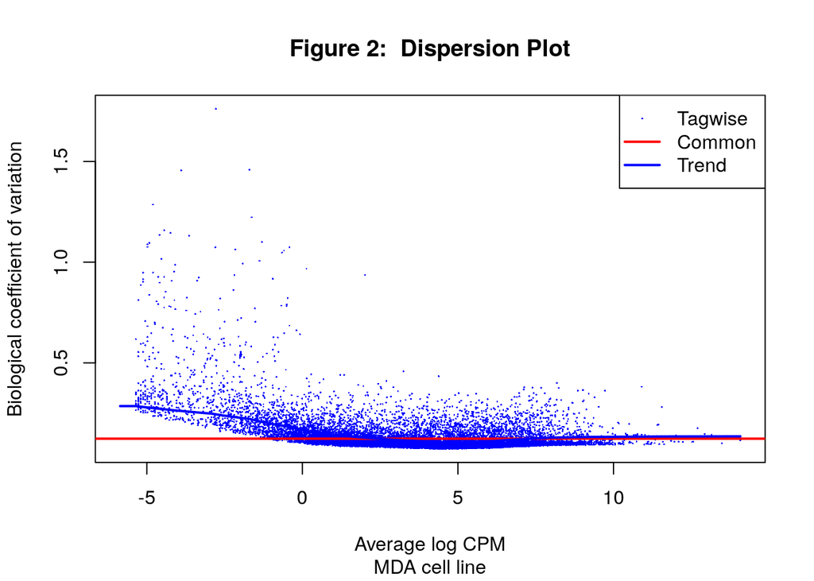

## Identifier mapping

```r
# map my ensembl id to hgnc symbol using the correct mart and biomart filter,
conversion_mda <- "mda_cell_line.rds"
if (file.exists(conversion_mda)) {
    mda_cell_line <- readRDS(conversion_mda)
} else {
    mda_cell_line <- getBM(attributes = c("ensembl_gene_id", "hgnc_symbol"), filters = "ensembl_gene_id",
        value = exp_data_filtered$gene_id, mart = ensembl)
    saveRDS(mda_cell_line, conversion_mda)
}
```

(Durinck et al. 2009)

[output not shown]

```r
# merge to include rest of the data
normalized_counts_merge <- merge(mda_cell_line, normalized_counts, by.x = 1, by.y = 0,
    all.y = TRUE)
# how many are missing
kable(normalized_counts_merge[1:5, 1:5], type = "html", caption = "Table 3 : missing hgnc symbols")

ensembl_id_missing_gene <- normalized_counts_merge$ensembl_gene_id[which(is.na(normalized_counts_merge$hgnc_symbol))]  #1207
no_symbol = length(ensembl_id_missing_gene)
# old hgnc from my original dataset
old_mapping <- merge(exp_data_filtered[, 1:2], data.frame(ensembl_id_missing_gene),
    by.x = 2, by.y = 1)
# some of the old hgnc symbol
kable(old_mapping[1:10, ], type = "html", caption = " Table 4: unmapped ensembl id  found in original dataset")
# how many ribosomal protein there are
count = nrow(old_mapping[grep(old_mapping$gene_name, pattern = "^RP"), ])
```

I merge the data set and 1207 observations are missing, 258are ribosomal genes but it is not really important for this dataset. The coverage now around 95%

```r
# missing hgnc symbol
missing_ids_subset <- normalized_counts_merge[which(is.na(normalized_counts_merge$hgnc_symbol)),
    ]
# merge the missing symbol with old mapping
missing_ids_subset_withids <- merge(old_mapping, missing_ids_subset, by.x = 1, by.y = 1)
# filter out the NAs caused by the merge
missing_ids_subset_withids <- missing_ids_subset_withids[-3]
# set the same column names
colnames(missing_ids_subset_withids)[1:2] <- colnames(normalized_counts_merge)[1:2]
# bind the old mapping with the rows that have missing hgnc symbol
finalized_normalized_counts <- rbind(normalized_counts_merge[which(!is.na(normalized_counts_merge$hgnc_symbol)),
    ], missing_ids_subset_withids)  #16948 rows
```

```r
# check NAs
any(is.na(finalized_normalized_counts$hgnc_symbol))
# check and filter duplicated ensembl id
duplicates_ensembl <- length(finalized_normalized_counts$ensembl_gene_id) - length(unique(finalized_normalized_counts$ensembl_gene_id))  # 83rows
finalized_normalized_counts <- distinct(finalized_normalized_counts, ensembl_gene_id,
    .keep_all = TRUE)  # 16865 rows





# write.table(finalized_normalized_counts, file = file.path(getwd(),'Data',
# 'GSE152201_finalized_normalized_counts_mda_2022.txt'), sep = '\t')
```

(Durinck et al. 2009; Isserlin 2022c; Xie 2021)

# Description of my data

link to the [data source](https://www.ncbi.nlm.nih.gov/geo/query/acc.cgi?acc=GSE152201)

paper : Article : STAT3 and GR cooperate to drive gene expression and growth of basal-like triple-negative breast cancer(Conway et al. 2020)

In the last assignment, I was working with gene expression data pulling from Geo with id GSE152201. his dataset describes the experiment about two breast cancer cell lines; HCC70 and MDA. HCC70 is a basal cell line while MDA is a meschemyal cell line. Each cell line was treated with a ethanol control, and a treatment (DEX) with three replicates each. DEX is a inducer of GR, the experiment is trying to find out what genes are unregulated by this inducer. Complemented by other experiments, they ultimately wanted to show that GR coordinates with STAT3 to active gene expression signature for basal-like triple-negative breast cancer.

Since this data contains two cell lines, I am just going to perform one differential expression for the MDA cell line.

```r
knitr::opts_chunk$set(warning = FALSE, message = FALSE, echo = TRUE, results = "hide",
    tidy = TRUE)
```

# A2 : Differentail Gene Expression

## Set up

All packages references in A2 (Morgan 2021; Gu et al. 2014; Gu, Eils, and Schlesner 2016; Ritchie et al. 2015; Xie 2021; Xie, Cheng, and Tan 2022; Kolberg et al. 2020; Huber et al. 2015; Wickham et al. 2019; Isserlin 2022b, 2022d)

```r
# rename for convinence
normalized_count_data <- finalized_normalized_counts
# select the normalized data
heatmap_matrix <- normalized_count_data[, 3:8]
# rename the column and row names
rownames(heatmap_matrix) <- normalized_count_data$ensembl_gene_id
colnames(heatmap_matrix)
colnames(heatmap_matrix) <- colnames(normalized_count_data[, 3:8])
```

## First scaled Heatmap

```r
# row normalized the data
heatmap_matrix <- t(scale(t(heatmap_matrix)))
heatmap_matrix <- data.frame(heatmap_matrix)
# store 104 NAs
MDA_heatmap_missing <- heatmap_matrix %>% filter_all(any_vars(is.na(.)))
# filter 104 NAs
heatmap_matrix <- heatmap_matrix %>% drop_na(.)
# some NAs, could be due to 0 variance select the first 2000?, plot showed
# nothing heatmap_matrix_2000<-heatmap_matrix[1:2000,]

# set up the color gradient
if (min(heatmap_matrix) == 0) {
    heatmap_col = colorRamp2(c(0, max(heatmap_matrix)), c("white", "red"))
} else {
    heatmap_col = colorRamp2(c(min(heatmap_matrix), 0, max(heatmap_matrix)), c("blue",
        "white", "red"))
}
# plot a heatmap
current_heatmap <- Heatmap(as.matrix(heatmap_matrix), show_row_dend = TRUE, show_column_dend = TRUE,
    col = heatmap_col, show_column_names = TRUE, show_row_names = FALSE, show_heatmap_legend = TRUE,
    row_title = "normalized clustered genes", column_title = "mda_samples")
current_heatmap
```

I did not include this image because the rendering time is long, I have thought about to include the first 2000 but the plot basically showed nothing.

(Gu, Eils, and Schlesner 2016; Gu et al. 2014; Isserlin 2022b)

## T test

```r
# get the column indexes for control and treatment group
etoh_samples <- grep(colnames(normalized_count_data), pattern = "EtoH")
dex_samples <- grep(colnames(normalized_count_data), pattern = "DEX")

# Find gene of interest, GR(NR3C1)
gr_gene_of_interest <- which(normalized_count_data$hgnc_symbol == "NR3C1")

# separate the data into control and treatment sample based on the given column
# indexes
gr_etoh_samples <- t(normalized_count_data[gr_gene_of_interest, etoh_samples])
colnames(gr_etoh_samples) <- c("etoh_samples")
# gr_etoh_samples

gr_dex_samples <- t(normalized_count_data[gr_gene_of_interest, dex_samples])
colnames(gr_dex_samples) <- c("dex_samples")
# gr_dex_samples

# Run a t test
t_test <- t.test(x = t(gr_etoh_samples), y = t(gr_dex_samples))
DT::datatable(broom::tidy(t_test), caption = "Table 1 : T test result for GR(NR3C1)",
    options = list(scrollX = T))
```

|  | estimate | estimate1 | estimate2 | statistic | p.value | parameter | conf.low | conf.high | method | alternative |
| --- | --- | --- | --- | --- | --- | --- | --- | --- | --- | --- |
| 1 | 39.1733214489785 | 134.386016557755 | 95.212695108777 | 6.45861750683446 | 0.0180811457174916 | 2.20228114659644 | 15.2441864186704 | 63.1024564792866 | Welch Two Sample t-test | two.sided |

(Robinson, Hayes, and Couch 2022; Isserlin 2022b; Xie, Cheng, and Tan 2022)

## Grouping

```r
# extract useful information from the column names
samples <- data.frame(lapply(colnames(normalized_count_data)[3:8], FUN = function(x) {
    unlist(strsplit(x, split = "_"))[c(1, 2, 4)]
}))  #?
colnames(samples) <- colnames(normalized_count_data)[3:8]
rownames(samples) <- c("cell_line ", "treatments", "replicates")
samples <- data.frame(t(samples))
knitr::kable(samples[1:6, ], output = "html", caption = "Table 2: Showing for ecah sample, which cell line, which replicats, and what condition")
```

Table 2: Showing for ecah sample, which cell line, which replicats, and what condition

|  | cell_line. | treatments | replicates |
| --- | --- | --- | --- |
| MDA231_DEX_4hr_rep1_SL35876 | MDA231 | DEX | rep1 |
| MDA231_DEX_4hr_rep2_SL35877 | MDA231 | DEX | rep2 |
| MDA231_DEX_4hr_rep3_SL35878 | MDA231 | DEX | rep3 |
| MDA231_EtoH_4hr_rep1_SL35879 | MDA231 | EtoH | rep1 |
| MDA231_EtoH_4hr_rep2_SL35880 | MDA231 | EtoH | rep2 |
| MDA231_EtoH_4hr_rep3_SL35881 | MDA231 | EtoH | rep3 |

(Xie 2021)

## PCA

The position of control(ETOH) and treatment(DEX) samples on the PCA plot is mostly apart.So I would use a simple model to fit

[figure not shown]

```r
# 2D representation of my data, serve as reference for model building later
plotMDS(heatmap_matrix, col = c(rep("blue", 3), rep("red", 3)))
legend("topright", c("ETOH", "DEX"), pch = 19, fill = c("blue", "red"))
title(main = " Figure 2 : Principle Component Analysis Plot", sub = "MAD cell line")
```

(Ritchie et al. 2015; Isserlin 2022b)

From the plot we can see there is clear seperation of the two groups, so I will fit a simple model

## Simple Model

```r
# filter duplicated row name (RNA,rRNA)
duplicate_num <- length(normalized_count_data$hgnc_symbol) - length(unique(normalized_count_data$hgnc_symbol))
# filter duplicated symbil
normalized_count_data <- distinct(normalized_count_data, hgnc_symbol, .keep_all = TRUE)  # 15512 rows left

# create a design matrix
model_design <- model.matrix(~samples$treatments)
knitr::kable(model_design[1:5, ], type = "html", caption = "model design")  # not showm\n in knitted version
# convert dataframe to matrix
expressionMatrix <- as.matrix(normalized_count_data[, 3:8])
# assign row names and column names
rownames(expressionMatrix) <- normalized_count_data$ensembl_gene_id
colnames(expressionMatrix) <- colnames(normalized_count_data)[3:8]
# create a exprssion set
minimalSet <- ExpressionSet(assayData = expressionMatrix)
# fit the model
fit <- lmFit(minimalSet, model_design)
```

There a 1353 duplicated hgnc id in my file, those are likely due to duplicated hgnc id I kept for my first assignment.

```r
# use empirical bays to find genes that are differentially expressed trend = TRUE
# is specific for RNA-seq data
fit2 <- eBayes(fit, trend = TRUE)
# get the top-hits after correction for multiple hypothesis testing
topfit <- topTable(fit2, coef = ncol(model_design), adjust.method = "BH", number = nrow(expressionMatrix))
# merge the hgnc symbol by ensembl id
output_hits <- merge(normalized_count_data[, 1:2], topfit, by.y = 0, by.x = 1, all.y = TRUE)
# order the p value from high to low
output_hits <- output_hits[order(output_hits$P.Value), ]
knitr::kable(output_hits[1:10, 2:8], type = "html", row.names = FALSE, caption = "Table 4: Simple model fit differential gene expression result using empirica bays")
# number of genes pass un-adjusted threshold
num_p_val <- length(which(output_hits$P.Value < 0.05))
# number of genes pass adjusted threshold
num_adj_p <- length(which(output_hits$adj.P.Val < 0.05))
# get the fit for my gene of interest
gr <- output_hits[which(output_hits$hgnc_symbol == "NR3C1"), ]


DT::datatable(gr, option = list(scrollX = T), caption = "Table 5: model fit result for GR gene")
```

Table 4: Simple model fit differential gene expression result using empirica bays

| hgnc_symbol | logFC | AveExpr | t | P.Value | adj.P.Val | B |
| --- | --- | --- | --- | --- | --- | --- |
| NUDT16 | -142.384330 | 105.054512 | -59.81526 | 0 | 1.83e-05 | 1.130874 |
| SCNN1G | -5.687960 | 2.843980 | -56.76938 | 0 | 1.83e-05 | 1.127061 |
| TSC22D3 | -169.955077 | 91.069378 | -55.90525 | 0 | 1.83e-05 | 1.125865 |
| NT5DC3 | -160.940736 | 147.873895 | -55.41369 | 0 | 1.83e-05 | 1.125160 |
| MT1X | -6.336576 | 4.173485 | -53.97383 | 0 | 1.83e-05 | 1.122984 |
| MT1E | -157.968254 | 95.207152 | -53.88173 | 0 | 1.83e-05 | 1.122839 |
| BIRC3 | -219.243719 | 133.252984 | -48.26544 | 0 | 2.63e-05 | 1.112382 |
| PXYLP1 | -15.922962 | 9.317015 | -48.01940 | 0 | 2.63e-05 | 1.111840 |
| MT2A | -208.178459 | 156.147866 | -46.95163 | 0 | 2.65e-05 | 1.109387 |
| FKBP5 | -1137.546636 | 629.001346 | -42.92610 | 0 | 3.60e-05 | 1.098466 |

|  | ensembl_gene_id | hgnc_symbol | logFC | AveExpr | t | P.Value | adj.P.Val | B |
| --- | --- | --- | --- | --- | --- | --- | --- | --- |
| 3167 | ENSG00000113580 | NR3C1 | 39.1733214489785 | 114.799355833266 | 7.18213917032184 | 0.000482650681523448 | 0.0134656067837981 | -0.519541483020702 |

(Xie, Cheng, and Tan 2022; Huber et al. 2015; Ritchie et al. 2015; Isserlin 2022b)

## Volcano plot

### Q3

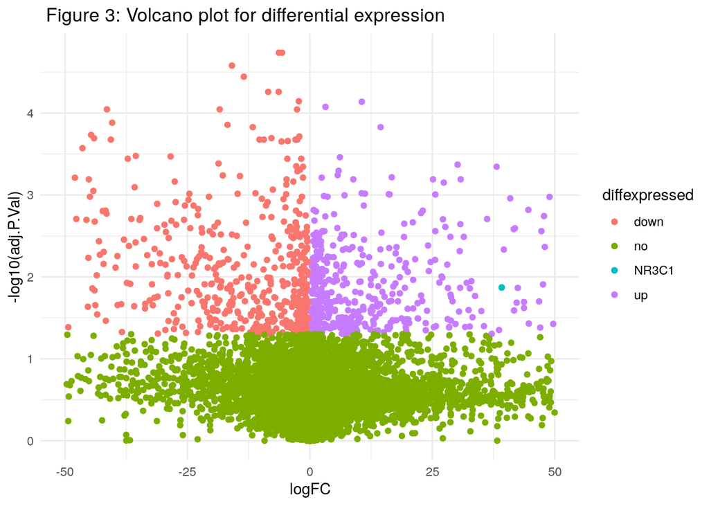

```r
# create a new column to show genes after correction that are up-regulated,
# down-regulated, and no change

output_hits$diffexpressed <- "no"
output_hits$diffexpressed[output_hits$logFC > 0 & output_hits$adj.P.Val < 0.05] <- "up"
output_hits$diffexpressed[output_hits$logFC < 0 & output_hits$adj.P.Val < 0.05] <- "down"
output_hits$diffexpressed[output_hits$hgnc_symbol == "NR3C1"] <- "NR3C1"

# use for plotting to allow my gene of interest to be on the top layer
df_layer_2 <- output_hits[output_hits$diffexpressed == "NR3C1", ]

# plot a volcano plot
ggplot() + geom_point(data = output_hits, aes(x = logFC, y = -log10(adj.P.Val), col = diffexpressed)) +
    geom_point(data = df_layer_2, aes(x = logFC, y = -log10(adj.P.Val), col = "NR3C1")) +
    theme_minimal() + xlim(-50, 50) + labs(title = " Figure 3: Volcano plot for differential expression")
```

(Wickham 2016)

## Heatmap for genes with p value < 0.05

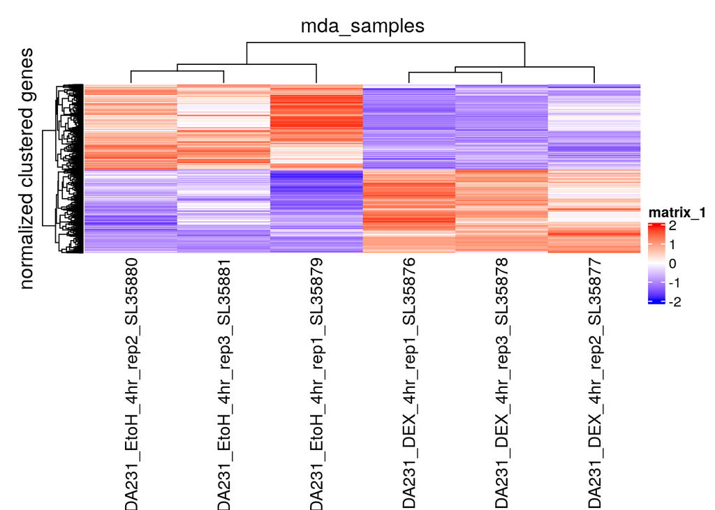

Figure 4: heatmap for significant differential expression with row normalization

```r
# filter the significant hits
top_hits <- output_hits$ensembl_gene_id[output_hits$P.Value < 0.05]
# create a heatmap matrix for genes that are significant
heatmap_matrix_tophits <- t(scale(t(heatmap_matrix[which(rownames(heatmap_matrix) %in%
    top_hits), ])))
# set up the color gradient
if (min(heatmap_matrix_tophits) == 0) {
    heatmap_col = colorRamp2(c(0, max(heatmap_matrix_tophits)), c("white", "red"))
} else {
    heatmap_col = colorRamp2(c(min(heatmap_matrix_tophits), 0, max(heatmap_matrix_tophits)),
        c("blue", "white", "red"))
}
# plot a heatmap for only those genes that are significant
current_heatmap <- Heatmap(as.matrix(heatmap_matrix_tophits), cluster_rows = TRUE,
    cluster_columns = TRUE, show_row_dend = TRUE, show_column_dend = TRUE, col = heatmap_col,
    show_column_names = TRUE, show_row_names = FALSE, show_heatmap_legend = TRUE,
    row_title = "normalized clustered genes", column_title = "mda_samples")
current_heatmap
```

(Gu, Eils, and Schlesner 2016; Gu et al. 2014; Isserlin 2022b)

### Q4

After we select for genes that are significant, the heatmap shows a more clear picture of the experiment. This is because the experiment might be well-performed to eliminate any variation that is not resulted from the manipulation. It is also shown by the PCA plot that the control and treatment is well-separated. Gene sets are up-regulated in the control sample are down-regulated in the treatment group. Gene sets are down-regulated in the control sample are up-regulated in the treatment group.

## Ordered heatmap for genes with adjusted p value < 0.05

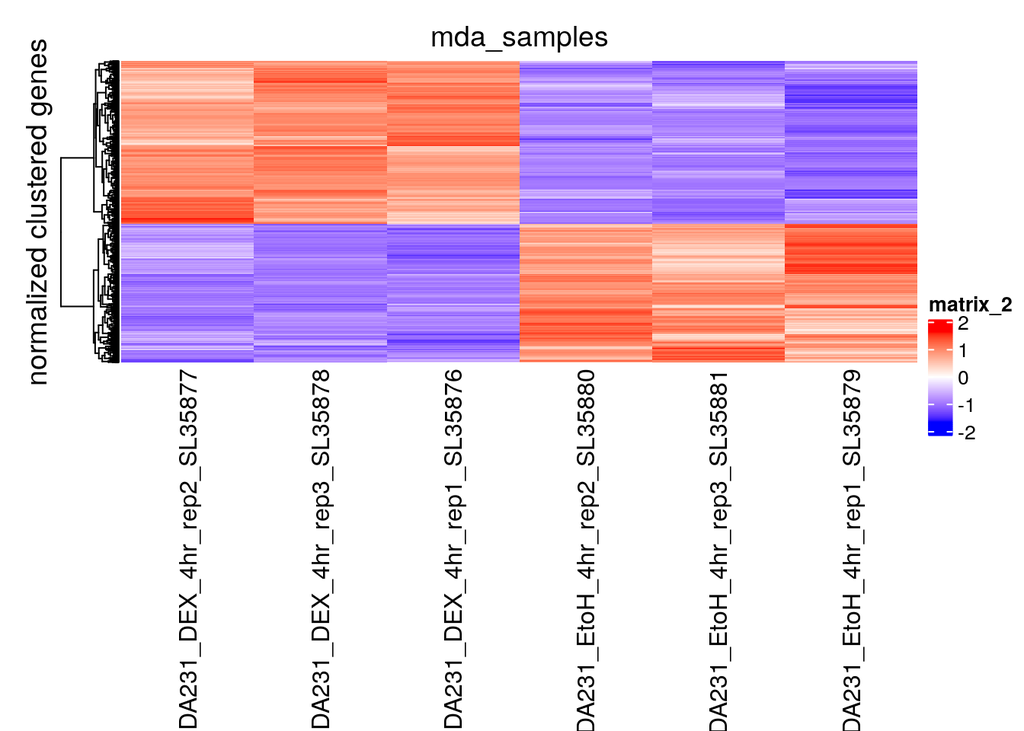

```r
top_hits <- output_hits$ensembl_gene_id[output_hits$adj.P.Val < 0.05]
heatmap_matrix_tophits <- t(scale(t(heatmap_matrix[which(rownames(heatmap_matrix) %in%
    top_hits), ])))
if (min(heatmap_matrix_tophits) == 0) {
    heatmap_col = colorRamp2(c(0, max(heatmap_matrix_tophits)), c("white", "red"))
} else {
    heatmap_col = colorRamp2(c(min(heatmap_matrix_tophits), 0, max(heatmap_matrix_tophits)),
        c("blue", "white", "red"))
}


# plot heatmap that orders columns based on what I have given (do not cluster
# columns)
current_heatmap <- Heatmap(as.matrix(heatmap_matrix_tophits), cluster_rows = TRUE,
    cluster_columns = TRUE, show_row_dend = TRUE, show_column_dend = FALSE, col = heatmap_col,
    show_column_names = TRUE, show_row_names = FALSE, show_heatmap_legend = TRUE,
    row_title = "normalized clustered genes", column_title = "mda_samples")
current_heatmap
```

(Gu, Eils, and Schlesner 2016; Gu et al. 2014; Isserlin 2022b)

There is a clear clusters of genes if we only inlcude genes that are significant after correction.

# A2: Threshold and over-representation analysis

## Enrichment analysis using gprofiler2

### Q1

I decided to use the gprofiler2 package for enrichment analysis because it would fit well with the rest of code and gprofiler2 actually come with some nice graphing function I used Benjamini-Hochberg(BH) for multiple hypothesis testing correction there are thousands of pathways. BH is not as strict as bonferroni so I would not get all pathway out and it corrects false positives.

### Q2

I choose GO biological processes , Reactome and Wikipathway.I choose those becuase I am interested in biological pathway annotation and those three are popular and free. I want my initial analysis to be high quality so I exclude electronic version of GO.

I am using the following version as shown in the [gprofiler web server](https://biit.cs.ut.ee/gprofiler/gost)-Data sources - Show data versions

*GO:BP – annotations: BioMart, classes:releases/2021-12-15

*REAC – annotations: BioMart,classes: 2022-1-3

*WP – 2021-12-10

Some code in this section references a publication about gprofiler2(Kolberg et al. 2020).

```r
# up-regulated subset
up_subset <- output_hits[which(output_hits$adj.P.Val < 0.05 & output_hits$logFC >
    0), ]
# down-regulated subset
down_subset <- output_hits[which(output_hits$adj.P.Val < 0.05 & output_hits$logFC <
    0), ]
# whole list
whole <- output_hits[which(output_hits$adj.P.Val < 0.05), ]
```

```r
# enrichment analysis for up regulated subset
gp_up = gost(up_subset$hgnc_symbol, organism = "hsapiens", correction_method = "false_discovery_rate",
    exclude_iea = TRUE, sources = c("GO:BP", "REAC", "WP"))
# link to the gprofiler server
gp_up_link = gost(up_subset$hgnc_symbol, organism = "hsapiens", correction_method = "false_discovery_rate",
    exclude_iea = TRUE, sources = c("GO:BP", "REAC", "WP"), as_short_link = TRUE)
# filter based on term size and order by p value
df_up <- gp_up$result
df_up <- df_up[which(df_up$term_size < 200), ]
df_up_ordered <- df_up[order(df_up$p_value), ]


up_genesets <- nrow(df_up)

# construct a table about enrichment results
DT::datatable(df_up_ordered[, c(2, 3, 4, 9, 10, 11)], caption = " Table 6 : Enrichment analysis for up-regulated genes",
    options = list(scrollX = T))
```

|  | significant | p_value | term_size | term_id | source | term_name |
| --- | --- | --- | --- | --- | --- | --- |
| 405 | True | 0.000144050598495344 | 24 | REAC:R-HSA-2173788 | REAC | Downregulation of TGF-beta receptor signaling |
| 128 | True | 0.000337118192595298 | 84 | GO:0010717 | GO:BP | regulation of epithelial to mesenchymal transition |
| 137 | True | 0.000483982509115571 | 7 | GO:1905603 | GO:BP | regulation of blood-brain barrier permeability |
| 406 | True | 0.000495586067409098 | 30 | REAC:R-HSA-2173789 | REAC | TGF-beta receptor signaling activates SMADs |
| 139 | True | 0.000554022128974072 | 33 | GO:0035633 | GO:BP | maintenance of blood-brain barrier |
| 161 | True | 0.00111267057217247 | 173 | GO:0043123 | GO:BP | positive regulation of I-kappaB kinase/NF-kappaB signaling |
| 165 | True | 0.00138624045544444 | 100 | GO:0030856 | GO:BP | regulation of epithelial cell differentiation |
| 166 | True | 0.00139128727525807 | 67 | GO:0061097 | GO:BP | regulation of protein tyrosine kinase activity |
| 168 | True | 0.00144693530043777 | 39 | GO:0061098 | GO:BP | positive regulation of protein tyrosine kinase activity |
| 169 | True | 0.00147622606907664 | 199 | GO:0050730 | GO:BP | regulation of peptidyl-tyrosine phosphorylation |

[output cut: 141 more lines]

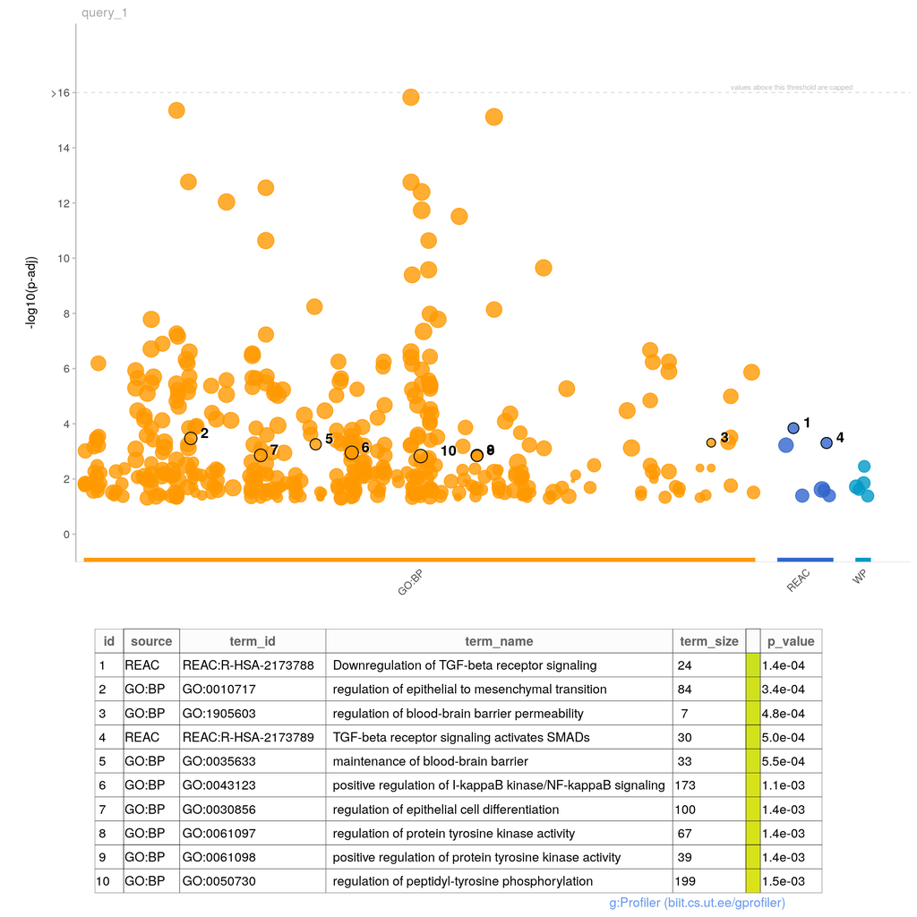

Figure 6: Enrichment plot for up-regulated genes

```r
# plot the enrichment result
p1 <- gostplot(gp_up, interactive = FALSE)
# highlight top ten hits
p1_up <- publish_gostplot(p1, highlight_terms = df_up_ordered$term_id[1:10])
```

```r
# publish_gosttable(gp_up)
```

```r
# for down regulated subset
gp_down = gost(down_subset$hgnc_symbol, organism = "hsapiens", correction_method = "false_discovery_rate",
    exclude_iea = TRUE, sources = c("GO:BP", "REAC", "WP"))
# link
gp_down_link = gost(down_subset$hgnc_symbol, organism = "hsapiens", correction_method = "false_discovery_rate",
    exclude_iea = TRUE, sources = c("GO:BP", "REAC", "WP"), as_short_link = TRUE)

# filter based on term size and order by p value
df_down <- gp_down$result
df_down <- df_down[which(df_down$term_size < 200), ]
df_down_ordered <- df_down[order(df_down$p_value), ]

down_genesets <- nrow(df_down)

# construct a table about enrichment results
DT::datatable(df_down_ordered[, c(2, 3, 4, 9, 10, 11)], caption = " Table 7 : Enrichment analysis for down-regulated genes",
    options = list(scrollX = T))
```

|  | significant | p_value | term_size | term_id | source | term_name |
| --- | --- | --- | --- | --- | --- | --- |
| 399 | True | 2.17296700376151e-20 | 71 | WP:WP2880 | WP | Glucocorticoid receptor pathway |
| 401 | True | 1.72333162930982e-06 | 114 | WP:WP4659 | WP | Gastrin signaling pathway |
| 4 | True | 5.86204718521801e-06 | 100 | GO:0030856 | GO:BP | regulation of epithelial cell differentiation |
| 390 | True | 7.07709580793759e-06 | 11 | REAC:R-HSA-5661231 | REAC | Metallothioneins bind metals |
| 402 | True | 1.31964110436638e-05 | 131 | WP:WP236 | WP | Adipogenesis |
| 9 | True | 2.87505487041761e-05 | 14 | GO:0010273 | GO:BP | detoxification of copper ion |
| 10 | True | 2.87505487041761e-05 | 14 | GO:1990169 | GO:BP | stress response to copper ion |
| 391 | True | 3.40305010326695e-05 | 14 | REAC:R-HSA-5660526 | REAC | Response to metal ions |
| 12 | True | 4.37729334290574e-05 | 15 | GO:0061687 | GO:BP | detoxification of inorganic compound |
| 15 | True | 9.59292113795978e-05 | 17 | GO:0097501 | GO:BP | stress response to metal ion |

[output cut: 176 more lines]

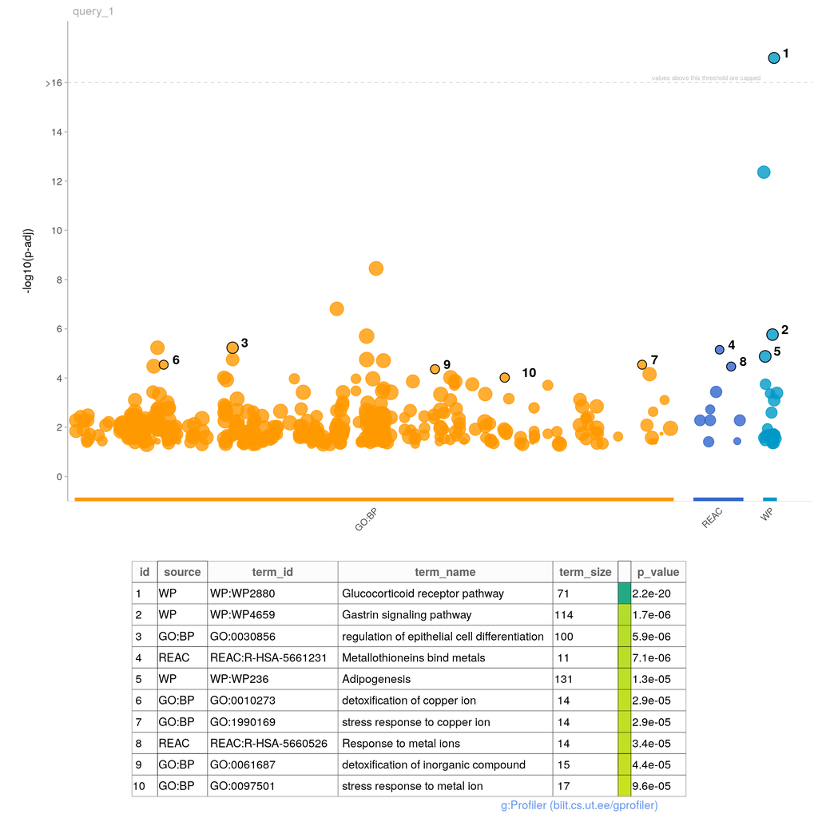

Figure 7: Enrichment plot for down-regulated genes

```r
# plot the enrichment result
p2 <- gostplot(gp_down, interactive = FALSE)
# highlight top ten hits
p2_down <- publish_gostplot(p2, highlight_terms = df_down_ordered$term_id[1:10])
```

```r
# for the whole set
gp_whole = gost(whole$hgnc_symbol, organism = "hsapiens", correction_method = "false_discovery_rate",
    exclude_iea = TRUE, sources = c("GO:BP", "REAC", "WP"))

gp_whole_link = gost(whole$hgnc_symbol, organism = "hsapiens", correction_method = "false_discovery_rate",
    exclude_iea = TRUE, sources = c("GO:BP", "REAC", "WP"), as_short_link = TRUE)

# filter based on term size and order by p vlaue
df_whole <- gp_whole$result
df_whole <- df_whole[which(df_whole$term_size < 200), ]
df_whole_ordered <- df_whole[order(df_whole$p_value), ]

whole_genesets <- nrow(df_whole)
# construct a table about enrichment results
DT::datatable(df_whole_ordered[, c(2, 3, 4, 9, 10, 11)], caption = " Table 8 : Enrichment analysis for down-regulated genes",
    options = list(scrollX = T))
```

|  | significant | p_value | term_size | term_id | source | term_name |
| --- | --- | --- | --- | --- | --- | --- |
| 747 | True | 2.21115897471476e-22 | 71 | WP:WP2880 | WP | Glucocorticoid receptor pathway |
| 27 | True | 1.0592840344531e-10 | 100 | GO:0030856 | GO:BP | regulation of epithelial cell differentiation |
| 151 | True | 5.65246120304824e-06 | 138 | GO:0043409 | GO:BP | negative regulation of MAPK cascade |
| 156 | True | 8.60116008409061e-06 | 191 | GO:0071559 | GO:BP | response to transforming growth factor beta |
| 161 | True | 1.29321420664307e-05 | 98 | GO:0003158 | GO:BP | endothelium development |
| 162 | True | 1.29321420664307e-05 | 43 | GO:0038066 | GO:BP | p38MAPK cascade |
| 163 | True | 1.36788908533354e-05 | 185 | GO:0071560 | GO:BP | cellular response to transforming growth factor beta stimulus |
| 170 | True | 1.78171322416704e-05 | 157 | GO:0007179 | GO:BP | transforming growth factor beta receptor signaling pathway |
| 171 | True | 1.8345221573012e-05 | 83 | GO:0045446 | GO:BP | endothelial cell differentiation |
| 179 | True | 2.29705373014285e-05 | 102 | GO:0002064 | GO:BP | epithelial cell development |

[output cut: 409 more lines]

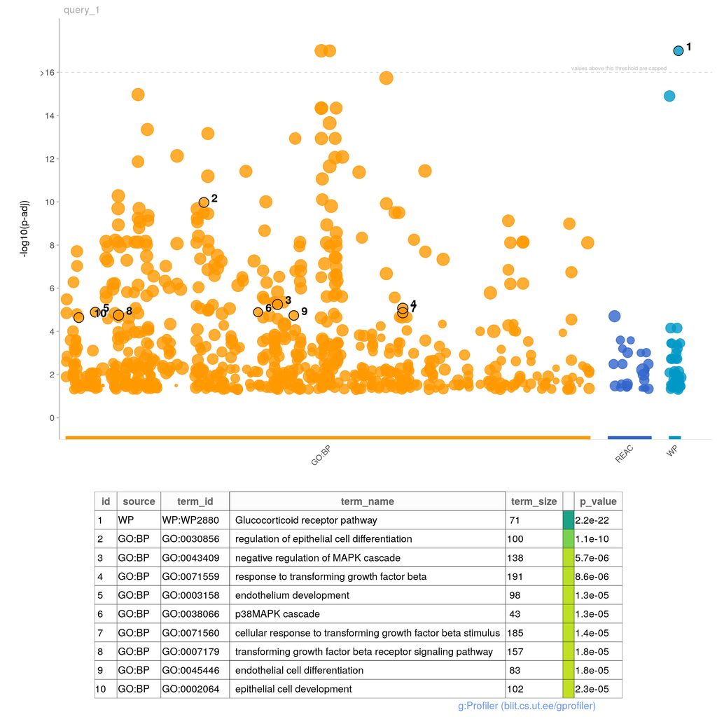

```r
# plot the enrichment result
p3 <- gostplot(gp_whole, interactive = FALSE)
# highlight top ten hits
p3_whole <- publish_gostplot(p3, highlight_terms = df_whole_ordered$term_id[1:10])
```

(Kolberg et al. 2020; Xie, Cheng, and Tan 2022)

I have included three links to the gprofiler web server my enrichment analysis results.

up : https://biit.cs.ut.ee/gplink/l/DG6OjEXIRq

down : https://biit.cs.ut.ee/gplink/l/-UKc9l8YTw

whole : https://biit.cs.ut.ee/gplink/l/_ewgyT81RS

### Q3

For term size between 0 and 200, threshold of 0.05 after BH correction. There are 151 up-regulated genesets. There are 186 down-regulated genesets. There are a total 419 genesets using the whole list.

### Q4

Comparing enrichment analysis results from using only up or down-regulated gene list versus using the whole list I see there are some differences in the top hits returned. Using the whole gene list gave us some new enrichment results such as MAPK cascade and miRNA transcription. MAPK cascade and miRNA all have regulatory roles in breast cancer progression(Jiang et al. 2020 ; Loh et al. 2019). This is likely due the reason that some particular genes are highly expressed while other genes in the same geneset were not. However, in combination they gave a stronger signal.

# Interpretation

### Q1 and Q2

Because MDA is a stem cell line. There are some other top hits that are related to stem cell characteristics. However, because here I just analyzed differential expression after the induction of GR not STAT3, My analysis cannot confidently support the final conclusion of the paper that STAT3 and GR coordinates to active basal-like triple-negative breast cancer.

### Journal link

[A2](https://github.com/bcb420-2022/Zhaojing_Chen.git)

# Citations

Biswas, Debajit K, Qian Shi, Shanon Baily, Ian Strickland, Sankar Ghosh, Arthur B Pardee, and J Dirk Iglehart. 2004. “NF-$\kappa$B Activation in Human Breast Cancer Specimens and Its Role in Cell Proliferation and Apoptosis.” *Proceedings of the National Academy of Sciences* 101 (27): 10137–42.

Chen, Yunshun, Aaron A T Lun, and Gordon K Smyth. 2016. “From Reads to Genes to Pathways: Differential Expression Analysis of Rna-Seq Experiments Using Rsubread and the edgeR Quasi-Likelihood Pipeline.” *F1000Research* 5: 1438. https://doi.org/10.12688/f1000research.8987.2.

Conway, Megan E, Joy M McDaniel, James M Graham, Katrin P Guillen, Patsy G Oliver, Stephanie L Parker, Peibin Yue, et al. 2020. “STAT3 and Gr Cooperate to Drive Gene Expression and Growth of Basal-Like Triple-Negative Breast Cancer.” *Cancer Research* 80 (20): 4355–70.

Davis, Sean, and Paul Meltzer. 2007. “GEOquery: A Bridge Between the Gene Expression Omnibus (Geo) and Bioconductor.” *Bioinformatics* 14: 1846–7.

Durinck, Steffen, Paul T. Spellman, Ewan Birney, and Wolfgang Huber. 2009. “Mapping Identifiers for the Integration of Genomic Datasets with the R/Bioconductor Package biomaRt.” *Nature Protocols* 4: 1184–91.

Gu, Zuguang, Roland Eils, and Matthias Schlesner. 2016. “Complex Heatmaps Reveal Patterns and Correlations in Multidimensional Genomic Data.” *Bioinformatics*.

Gu, Zuguang, Lei Gu, Roland Eils, Matthias Schlesner, and Benedikt Brors. 2014. “Circlize Implements and Enhances Circular Visualization in R.” *Bioinformatics* 30 (19): 2811–2.

Huber, W., V. J. Carey, R. Gentleman, S. Anders, M. Carlson, B. S. Carvalho, H. C. Bravo, et al. 2015. “Orchestrating High-Throughput Genomic Analysis with Bioconductor.” *Nature Methods* 12 (2): 115–21. http://www.nature.com/nmeth/journal/v12/n2/full/nmeth.3252.html.

Hynes, Nancy E. 2000. “Tyrosine Kinase Signalling in Breast Cancer.” *Breast Cancer Research* 2 (3): 1–4.

Isserlin, Ruth. 2022a. “BCB420 - Computational Systems Biology. Lecture 4 - Exploring the Data and Basics of Normalization.” https://q.utoronto.ca/courses/248455/files/19273570?module_item_id=3476594.

———. 2022b. “BCB420 - Computational Systems Biology. Lecture 6 - Differential Expression.” https://q.utoronto.ca/courses/248455/files/19309003?module_item_id=3480535.

———. 2022c. “BCB420 - Computational Systems Biology Lecture. Lecture 5 - Data Exploration and Identifier Mapping.” https://q.utoronto.ca/courses/248455/files/19306012?module_item_id=3480061.

———. 2022d. “BCB420 - Computational Systems Biology Lecture. Lecture 7 - Annotation Dataset and Intro to Pathway Analysis.” https://q.utoronto.ca/courses/248455/files/18120892?module_item_id=3210881.

Jiang, Weihua, Xiaowen Wang, Chenguang Zhang, Laiti Xue, and Liang Yang. 2020. “Expression and Clinical Significance of Mapk and Egfr in Triple-Negative Breast Cancer.” *Oncology Letters* 19 (3): 1842–8.

Kolberg, Liis, Uku Raudvere, Ivan Kuzmin, Jaak Vilo, and Hedi Peterson. 2020. “Gprofiler2–an R Package for Gene List Functional Enrichment Analysis and Namespace Conversion Toolset G: Profiler.” *F1000Research* 9.

Loh, Hui-Yi, Brendan P Norman, Kok-Song Lai, Nik Mohd Afizan Nik Abd Rahman, Noorjahan Banu Mohamed Alitheen, and Mohd Azuraidi Osman. 2019. “The Regulatory Role of microRNAs in Breast Cancer.” *International Journal of Molecular Sciences* 20 (19): 4940.

Morgan, Martin. 2021. *BiocManager: Access the Bioconductor Project Package Repository*. https://CRAN.R-project.org/package=BiocManager.

Ritchie, Matthew E, Belinda Phipson, Di Wu, Yifang Hu, Charity W Law, Wei Shi, and Gordon K Smyth. 2015. “limma Powers Differential Expression Analyses for RNA-Sequencing and Microarray Studies.” *Nucleic Acids Research* 43 (7): e47. https://doi.org/10.1093/nar/gkv007.

Robinson, David, Alex Hayes, and Simon Couch. 2022. *Broom: Convert Statistical Objects into Tidy Tibbles*. https://CRAN.R-project.org/package=broom.

Wickham, Hadley. 2016. *Ggplot2: Elegant Graphics for Data Analysis*. Springer-Verlag New York. https://ggplot2.tidyverse.org.

Wickham, Hadley, Mara Averick, Jennifer Bryan, Winston Chang, Lucy D’Agostino McGowan, Romain François, Garrett Grolemund, et al. 2019. “Welcome to the tidyverse.” *Journal of Open Source Software* 4 (43): 1686. https://doi.org/10.21105/joss.01686.

Xie, Yihui. 2021. *Knitr: A General-Purpose Package for Dynamic Report Generation in R*. https://yihui.org/knitr/.

Xie, Yihui, Joe Cheng, and Xianying Tan. 2022. *DT: A Wrapper of the Javascript Library ’Datatables’*. https://CRAN.R-project.org/package=DT.

Zhu, Yuelin, Sean Davis, Robert Stephens, Paul S. Meltzer, and Yidong Chen. 2008. “GEOmetadb: Powerful Alternative Search Engine for the Gene Expression Omnibus.” *Bioinformatics (Oxford, England)* 24 (23): 2798–2800. https://doi.org/10.1093/bioinformatics/btn520.